# Liverpool-meccsek gólkülönbségeinek modellezése

Kőrösi Péter, Vadász Tamara

2020.01.08

# Az elemzés célja:

- Labdarúgó-mérkőzések eredményeinek előrejelzése
  - egy csapat kiválasztása (Liverpool)
  - az adott csapat meccseinek elemzése korábbi eredmények alapján
- 2 modell készítése az eddigi szezonok alapján
  - lineáris regresszió és PCA
- a becsült modell alapján predikció az idei szezonra

# Az adatok

## Forrás: [football-data.co.uk](https://www.football-data.co.uk/englandm.php)

Premier League 2000/01 - 2019/20 Liverpool-meccsek

*Az adatokat letöltő fájl: data_download.ipynb (python)*

A változók:

- Szezon (year)
- Meccs (match)
  - a meccs sorszáma az adott szezonon belül
- Hazai páya (home)
  - dummy (1: Liverpool hazai pálya, 0: Liverpool idegenben)
- Ellenfél (OTHER)
- Gólkülönbség (goal_difference)
  - Liverpool góljainak száma - ellenfél góljainak száma
- Félidei gólkülönbség (half_time_goal_difference)
  - Liverpool góljainak száma a félidőben - ellenfél góljainak száma a félidőben
- A meccs végén a Liverpool pontszáma a szezonban (points)
- győzelem: +3 pont
- döntetlen: +1 pont
- vereség: 0 pont

A következő változók mindkét csapatra (Liverpool: L_*, Ellenfél: O_*)

- Lőtt gólók száma (goals)
- Lőtt gólok száma félidőben (half_time_goals)
- Lövések száma (shots)
- Kaput eltaláló lövések száma (shots_on_target)
- Szögletek (corners)
- Elkövetett szabálytalanságok (fouls_commited)
- Sárga lapok (yellow_cards)
- Piros lapok (red_cards)

# TRAIN adattábla kialakítása

## train adat: 2003/04 - 2018/19 szezonok

A letöltött adatokból több új magyarázó változót is készítünk.

### A következő függvény 3 új változót hoz létre:

- Mindhárom változót a Liverpool és az adott ellenfél közti korábbi meccsek alapján számoljuk
- Meccsenkénti átlagos érték érték az előző 3 szezon alapján
  - A Liverpool által lőtt gólok átlagos száma
  - Az ellenfél által lőtt gólok átlagos száma
  - A Liverpool kaput eltaláló lövéseinek átlagos száma
- Amennyiben a Liverpool nem játszott az adott csapattal a vizsgált időszakban, ott 0 szerepel mindegyik változónál.

```r
get_team_data <- function(season){
  team_data <- data.table(team=character(),
                          mean_goals_scored=numeric(),
                          mean_goals_received=numeric(),
                          mean_shots_on_target=numeric())

  for (l in 1:19){
    temp <- seasonsbefore[OTHER == unique(season$OTHER)[l]]
    row <- data.table(team=unique(season$OTHER)[l],
                      mean_goals_scored=mean(temp$L_goals),
                      mean_goals_received=mean(temp$O_goals),
                      mean_shots_on_target=mean(temp$L_shots_on_target))
    team_data <- rbindlist(list(team_data, row))
  }

  team_data[is.na(team_data)] <- 0


  for (l in 1:19){
    season[OTHER==unique(season$OTHER)[l],
           mean_goals_scored:=team_data[team==unique(season$OTHER)[l], mean_goals_scored]]
    season[OTHER==unique(season$OTHER)[l],
           mean_goals_received:=team_data[team==unique(season$OTHER)[l], mean_goals_received]]
    season[OTHER==unique(season$OTHER)[l],
           mean_shots_on_target:=team_data[team==unique(season$OTHER)[l], mean_shots_on_target]]
  }
  return(season)
}
```

### Az előző függvény lefuttatása a train adattáblára

```r
train_data <- data.table()

for (i in 0:15){
  season <- data[year == paste(formatC(3+i, width=2, flag="0"), formatC(4+i, width=2, flag="0"), sep="-")]
  seasonsbefore <- data[year %in% c(paste(formatC(0+i, width=2, flag="0"), formatC(1+i, width=2, flag="0"), sep="-"),
                                    paste(formatC(1+i, width=2, flag="0"), formatC(2+i, width=2, flag="0"), sep="-"),
                                    paste(formatC(2+i, width=2, flag="0"), formatC(3+i, width=2, flag="0"), sep="-"))]

  season <- get_team_data(season)

  train_data <- rbindlist(list(train_data, season))
}
```

## A korábbi meccsek eredményeit leíró változók létrehozása

Az előző 3 meccs eredményei:

- Gólkülönbség
- Liverpool által kaput eltaláló lövések száma

Az előző 1 meccs eredménye:

- A Liverpool által kapott sárga lapok

```r
train_data[, goal_difference_lag1 := lag(train_data$goal_difference, n=1)]
train_data[, goal_difference_lag2 := lag(train_data$goal_difference, n=2)]
train_data[, goal_difference_lag3 := lag(train_data$goal_difference, n=3)]
train_data[, L_shots_on_target_lag1 := lag(train_data$L_shots_on_target, n=1)]
train_data[, L_shots_on_target_lag2 := lag(train_data$L_shots_on_target, n=2)]
train_data[, L_shots_on_target_lag3 := lag(train_data$L_shots_on_target, n=3)]
train_data[, yellow_cards_lag1 := lag(train_data$L_yellow_cards, n=1)]
train_data[is.na(train_data)] <- 0
```

## A modellekhez felhasznált adattábla kialakítása:

A felhasznált változók:

- Hazai páya
- Liverpool által lőtt gólok átlagos száma
- Az ellenfél által lőtt gólok átlagos száma
- A Liverpool kaput eltaláló lövéseinek átlagos száma
- Az előző 3 meccs gólkülönbségei
- Az előző 3 meccsen a Liverpool kaput eltaláló lövéseinek száma
- Az előző meccsen a Liverpool által kapott sárga lapok száma

```r
to_model <- train_data[, .(goal_difference,
                           home,
                           mean_goals_scored,
                           mean_goals_received,
                           mean_shots_on_target,
                           goal_difference_lag1,
                           goal_difference_lag2,
                           goal_difference_lag3,
                           L_shots_on_target_lag1,
                           L_shots_on_target_lag2,
                           L_shots_on_target_lag3,
                           yellow_cards_lag1)]
```

# TESZT adattábla kialakítása

## teszt adat: 2019/20-as szezon

Az előzőekben leírt adatszerkezet kialakítása

```r
# test_data letrehozasa
season <- data[year == "19-20"]
seasonsbefore <- data[year %in% c("16-17", "17-18", "18-19")]

test_data <- get_team_data(season)

test_data[, goal_difference_lag1 := lag(test_data$goal_difference, n=1)]
test_data[, goal_difference_lag2 := lag(test_data$goal_difference, n=2)]
test_data[, goal_difference_lag3 := lag(test_data$goal_difference, n=3)]
test_data[, L_shots_on_target_lag1 := lag(test_data$L_shots_on_target, n=1)]
test_data[, L_shots_on_target_lag2 := lag(test_data$L_shots_on_target, n=2)]
test_data[, L_shots_on_target_lag3 := lag(test_data$L_shots_on_target, n=3)]
test_data[, yellow_cards_lag1 := lag(test_data$L_yellow_cards, n=1)]
test_data[is.na(test_data)] <- 0

to_model_test <- test_data[, .(goal_difference,
                               home,
                               mean_goals_scored,
                               mean_goals_received,
                               mean_shots_on_target,
                               goal_difference_lag1,
                               goal_difference_lag2,
                               goal_difference_lag3,
                               L_shots_on_target_lag1,
                               L_shots_on_target_lag2,
                               L_shots_on_target_lag3,
                               yellow_cards_lag1)]
```

# A kapott változók vizsgálata

## A gólkülönbségek eloszlása (train adatok)

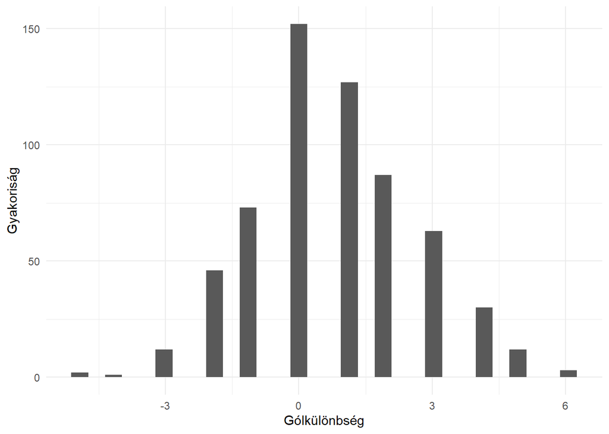

## Az átlagos gólkülönbség hazai pályán és idegenben

```r
train_data[, mean(goal_difference), by=home]
```

```
##    home        V1
## 1:    1 1.2598684
## 2:    0 0.2960526
```

## A gólkülönbségek eloszlása hazai pályán és idegenben

- 0: idegenben
- 1: hazai pálya

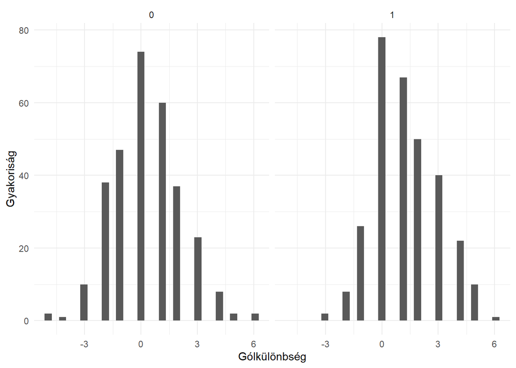

# Lineáris regresszió

A teljes train adaton Stepwise szelekció: AIC alapján

```r
lm_full <- lm(goal_difference ~ ., data=to_model)
step <- stepAIC(lm_full, trace=FALSE)

summary(step)
```

```
##
## Call:
## lm(formula = goal_difference ~ home + mean_goals_received + goal_difference_lag1,
##     data = to_model)
##
## Residuals:
##     Min      1Q  Median      3Q     Max
## -5.4592 -1.2213 -0.1988  1.0371  5.9537
##
## Coefficients:
##                      Estimate Std. Error t value Pr(>|t|)
## (Intercept)           0.50509    0.15376   3.285  0.00108 **
## home                  0.99909    0.14263   7.005 6.62e-12 ***
## mean_goals_received  -0.30585    0.12249  -2.497  0.01279 *
## goal_difference_lag1  0.06498    0.03942   1.649  0.09977 .
## ---
## Signif. codes:  0 '***' 0.001 '**' 0.01 '*' 0.05 '.' 0.1 ' ' 1
##
## Residual standard error: 1.739 on 604 degrees of freedom
## Multiple R-squared:  0.08402,    Adjusted R-squared:  0.07947
## F-statistic: 18.47 on 3 and 604 DF,  p-value: 1.789e-11
```

## A gólkülönbségek előrejelzése a teszt adatokon (19/20-as szezon)

```r
lm_pred <- predict(step, to_model_test)
```

# PCA

## A PCA elemzés:

```r
pca <- prcomp(to_model, scale = TRUE)
```

## A kapott komponensek vizsgálata

A komponensek által magyarázott variancia kiszámítása és ábrázolása

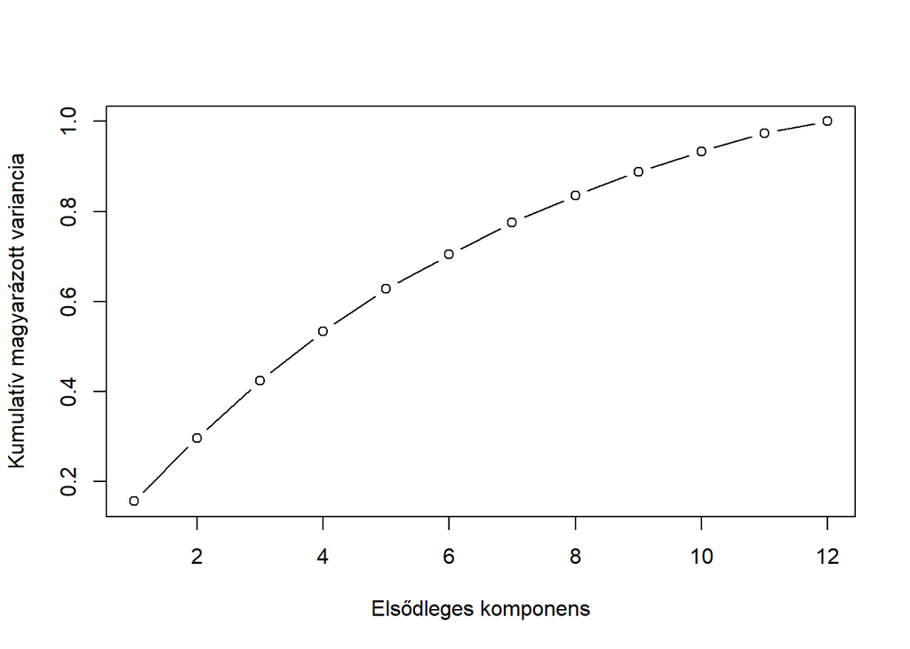

## A modell kialakítása a kapott komponensekből

```r
train.data <- data.frame(goal_difference = to_model$goal_difference, pca$x)
rpart.model <- rpart(goal_difference ~ .,data = train.data, method = "anova")
```

## A gólkülönbség előrejelzése a PCA modell alapján a teszt adatokon

```r
test.data <- predict(pca, newdata = to_model_test)
test.data <- as.data.frame(test.data)

rpart.prediction <- predict(rpart.model, test.data)
pca_pred <- rpart.prediction
```

# Eredmények

A két modell által becsült adatok összehasonlítása a megfigyelt eredménnyel

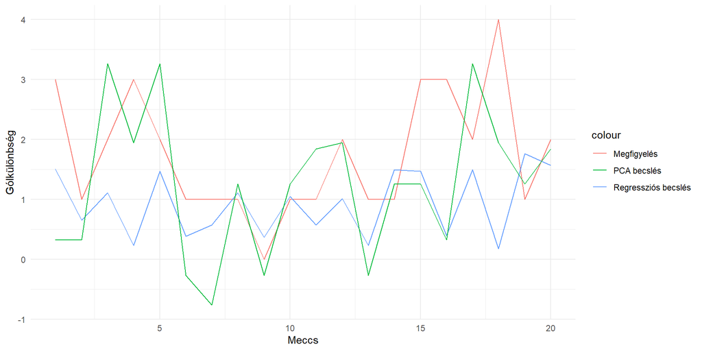

## A modellek értékelése

```r
c(mean(sqrt(abs(results$goal_difference - results$lm_prediction))),
  mean(sqrt(abs(results$goal_difference - results$pca_prediction))))
```

```
## [1] 0.9013289 0.9462802
```

A kapott eredmények alapján a lineáris modell jobb becslést ad.